# Binary Classification Deep Learning Model for Horses or Humans Using TensorFlow Take 3

### August 27, 2020

Template Credit: Adapted from a template made available by Dr. Jason Brownlee of Machine Learning Mastery. [https://machinelearningmastery.com/]

SUMMARY: The purpose of this project is to construct a predictive model using various machine learning algorithms and to document the end-to-end steps using a template. The Horses or Humans dataset is a binary classification situation where we are trying to predict one of the two possible outcomes.

INTRODUCTION: When learning Computer Vision, especially the training of DNNs and CNNs to recognize and classify images, there is a shortage of suitable datasets. Laurence Moroney wanted to fix that problem by creating a dataset that could be used for teaching binary classifiers that were unique and distinct from existing datasets. Laurence also wished to see if he could use Photo-real CGI to train a neural network that could then recognize and classify real images with the same subject matter.

The set contains 500 rendered images of various species of horses in different poses in multiple locations. It also includes 527 rendered images of humans in various poses and locations. Emphasis has been taken to ensure the diversity of humans, and to that end, there are both men and women as well as different ethnic groups present in the training set. The validation set adds six different figures of varying gender, race, and pose to ensure the breadth of data.

In iteration Take1, we constructed and tuned machine learning models for this dataset using TensorFlow with three VGG blocks. Laurence also demonstrated the dataset using a model with five VGG blocks, each block with just one convolution layer. We also observed the best result that we could obtain using different VGG-3 models with a different number of convolution layers.

In iteration Take2, we constructed and tuned machine learning models for this dataset using TensorFlow with four VGG blocks. Laurence also demonstrated the dataset using a model with five VGG blocks, each block with just one convolution layer. We also observed the best result that we could obtain using different VGG-4 models with a different number of convolution layers.

In this Take3 iteration, we will construct and tune machine learning models for this dataset using TensorFlow with three to five VGG blocks with Dropout layers. Laurence also demonstrated the dataset using a model with five VGG blocks, each block with just one convolution layer. We will observe the best result that we could obtain using different VGG models with Dropout.

ANALYSIS: From iteration Take1, the performance of the baseline model achieved an accuracy score of 82.03% on the validation dataset after 15 epochs. After a series of modeling trials, the TensorFlow model with three VGG blocks and two convolution layers processed the validation dataset with an accuracy score of 85.94%.

From iteration Take2, the performance of the baseline model achieved an accuracy score of 83.59% on the validation dataset after 15 epochs. After a series of modeling trials, the TensorFlow model with four VGG blocks and two convolution layers processed the validation dataset with an accuracy score of 86.33%.

Dataset Used: Horses or Humans Dataset

Dataset ML Model: Binary Classification with numerical attributes

Dataset Reference: http://www.laurencemoroney.com/horses-or-humans-dataset/

A deep-learning modeling project generally can be broken down into five major tasks:

1. Prepare Environment
2. Load and Prepare Data
3. Define and Train Model
4. Evaluate and Optimize Model
5. Finalize Model and Make Predictions

# Task 1. Prepare Environment

```python
# Install the packages to support accessing environment variable and SQL databases
!pip install python-dotenv PyMySQL
```

```python
# Retrieve GPU configuration information from Colab
gpu_info = !nvidia-smi
gpu_info = '\n'.join(gpu_info)
if gpu_info.find('failed') >= 0:
    print('Select the Runtime → "Change runtime type" menu to enable a GPU accelerator, ')
    print('and then re-execute this cell.')
else:
    print(gpu_info)
```

```
Sat Aug 22 03:50:34 2020
+-----------------------------------------------------------------------------+
| NVIDIA-SMI 450.57       Driver Version: 418.67       CUDA Version: 10.1     |
|-------------------------------+----------------------+----------------------+
| GPU  Name        Persistence-M| Bus-Id        Disp.A | Volatile Uncorr. ECC |
| Fan  Temp  Perf  Pwr:Usage/Cap|         Memory-Usage | GPU-Util  Compute M. |
|                               |                      |               MIG M. |
|===============================+======================+======================|
|   0  Tesla P100-PCIE...  Off  | 00000000:00:04.0 Off |                    0 |
| N/A   41C    P0    28W / 250W |      0MiB / 16280MiB |      0%      Default |
|                               |                      |                 ERR! |
+-------------------------------+----------------------+----------------------+

+-----------------------------------------------------------------------------+
| Processes:                                                                  |
|  GPU   GI   CI        PID   Type   Process name                  GPU Memory |
|        ID   ID                                                   Usage      |
|=============================================================================|
|  No running processes found                                                 |
+-----------------------------------------------------------------------------+
```

```python
# Retrieve memory configuration information from Colab
from psutil import virtual_memory
ram_gb = virtual_memory().total / 1e9
print('Your runtime has {:.1f} gigabytes of available RAM\n'.format(ram_gb))

if ram_gb < 20:
    print('To enable a high-RAM runtime, select the Runtime → "Change runtime type"')
    print('menu, and then select High-RAM in the Runtime shape dropdown. Then, ')
    print('re-execute this cell.')
else:
    print('You are using a high-RAM runtime!')
```

```
Your runtime has 13.7 gigabytes of available RAM

To enable a high-RAM runtime, select the Runtime → "Change runtime type"
menu, and then select High-RAM in the Runtime shape dropdown. Then,
re-execute this cell.
```

```python
# Retrieve CPU information from the system
ncpu = !nproc
print("The number of available CPUs is:", ncpu[0])
```

```
The number of available CPUs is: 2
```

```python
# Direct Colab to use TensorFlow v2
%tensorflow_version 2.x
```

```python
# Set the random seed number for reproducible results
seedNum = 888
```

```python
# Load libraries and packages
import random
random.seed(seedNum)
import numpy as np
np.random.seed(seedNum)
import os
import sys
import zipfile
import boto3
import pandas as pd
import matplotlib.pyplot as plt
import matplotlib.image as mpimg
from datetime import datetime
from dotenv import load_dotenv
import tensorflow as tf
tf.random.set_seed(seedNum)
from tensorflow import keras
from tensorflow.keras.preprocessing.image import ImageDataGenerator
```

```python
# Begin the timer for the script processing
startTimeScript = datetime.now()

# Check the number of GPUs accessible through TensorFlow
print("Num GPUs Available: ", len(tf.config.experimental.list_physical_devices('GPU')))

# Set up the number of CPU cores available for multi-thread processing
n_jobs = 1

# Set up the flag to stop sending progress emails (setting to True will send status emails!)
notifyStatus = False

# Set up the parent directory location for loading the dotenv files
useGDrive = False
if useGDrive:
    # Mount Google Drive locally for storing files
    from google.colab import drive
    drive.mount('/content/gdrive')
    gdrivePrefix = '/content/gdrive/My Drive/Colab_Downloads/'
    env_path = '/content/gdrive/My Drive/Colab Notebooks/'
    dotenv_path = env_path + "python_script.env"
    load_dotenv(dotenv_path=dotenv_path)

# Set up the dotenv file for retrieving environment variables
useLocalPC = False
if useLocalPC:
    env_path = "/Users/david/PycharmProjects/"
    dotenv_path = env_path + "python_script.env"
    load_dotenv(dotenv_path=dotenv_path)

# Set various default Keras modeling parameters
default_loss = 'binary_crossentropy'
default_metrics = ['accuracy']
default_optimizer = tf.keras.optimizers.Adam(learning_rate=0.001)
default_kernel_init = tf.keras.initializers.HeUniform(seed=seedNum)
default_epoch = 15
default_batch = 32
default_image_size = (300, 300)

# Define the labels to use for graphing the data
train_metric = "accuracy"
train_loss = "loss"
```

```
Num GPUs Available:  1
```

```python
# Set up the email notification function
def status_notify(msg_text):
    access_key = os.environ.get('SNS_ACCESS_KEY')
    secret_key = os.environ.get('SNS_SECRET_KEY')
    aws_region = os.environ.get('SNS_AWS_REGION')
    topic_arn = os.environ.get('SNS_TOPIC_ARN')
    if (access_key is None) or (secret_key is None) or (aws_region is None):
        sys.exit("Incomplete notification setup info. Script Processing Aborted!!!")
    sns = boto3.client('sns', aws_access_key_id=access_key, aws_secret_access_key=secret_key, region_name=aws_region)
    response = sns.publish(TopicArn=topic_arn, Message=msg_text)
    if response['ResponseMetadata']['HTTPStatusCode'] != 200 :
        print('Status notification not OK with HTTP status code:', response['ResponseMetadata']['HTTPStatusCode'])
```

```python
# Reset the random number generators
def reset_random(x):
    random.seed(x)
    np.random.seed(x)
    tf.random.set_seed(x)
```

```python
if (notifyStatus): status_notify("Task 1. Prepare Environment completed! "+datetime.now().strftime('%a %B %d, %Y %I:%M:%S %p'))
```

# Task 2. Load and Prepare Data

```python
if (notifyStatus): status_notify("Task 2. Load and Prepare Data has begun! "+datetime.now().strftime('%a %B %d, %Y %I:%M:%S %p'))
```

```python
!rm -rf image/
!rm horse-or-human-training.zip
!rm horse-or-human-validation.zip
```

```python
!mkdir image/
!mkdir image/training/
!mkdir image/validation/
```

```python
!wget https://dainesanalytics.com/datasets/laurencemoroney-horses-humans-dataset/horse-or-human-training.zip
```

```
--2020-08-22 03:50:42--  https://dainesanalytics.com/datasets/laurencemoroney-horses-humans-dataset/horse-or-human-training.zip
Resolving dainesanalytics.com (dainesanalytics.com)... 13.224.8.47, 13.224.8.76, 13.224.8.52, ...
Connecting to dainesanalytics.com (dainesanalytics.com)|13.224.8.47|:443... connected.
HTTP request sent, awaiting response... 200 OK
Length: 149574867 (143M) [application/zip]
Saving to: ‘horse-or-human-training.zip’

horse-or-human-trai 100%[===================>] 142.65M  16.2MB/s    in 9.0s

2020-08-22 03:50:51 (15.9 MB/s) - ‘horse-or-human-training.zip’ saved [149574867/149574867]
```

```python
!wget https://dainesanalytics.com/datasets/laurencemoroney-horses-humans-dataset/horse-or-human-validation.zip
```

```
--2020-08-22 03:50:52--  https://dainesanalytics.com/datasets/laurencemoroney-horses-humans-dataset/horse-or-human-validation.zip
Resolving dainesanalytics.com (dainesanalytics.com)... 13.224.8.47, 13.224.8.52, 13.224.8.76, ...
Connecting to dainesanalytics.com (dainesanalytics.com)|13.224.8.47|:443... connected.
HTTP request sent, awaiting response... 200 OK
Length: 11480187 (11M) [application/zip]
Saving to: ‘horse-or-human-validation.zip’

horse-or-human-vali 100%[===================>]  10.95M  --.-KB/s    in 0.09s

2020-08-22 03:50:52 (121 MB/s) - ‘horse-or-human-validation.zip’ saved [11480187/11480187]
```

```python
local_zip = 'horse-or-human-training.zip'
zip_ref = zipfile.ZipFile(local_zip, 'r')
train_dir = 'image/training/'
zip_ref.extractall(train_dir)
local_zip = 'horse-or-human-validation.zip'
zip_ref = zipfile.ZipFile(local_zip, 'r')
validation_dir = 'image/validation/'
zip_ref.extractall(validation_dir)
zip_ref.close()
```

```python
# Directory with our training horse pictures
train_horse_dir = os.path.join(train_dir, 'horses')

# Directory with our training human pictures
train_human_dir = os.path.join(train_dir, 'humans')

# Directory with our training horse pictures
validation_horse_dir = os.path.join(validation_dir, 'horses')

# Directory with our training human pictures
validation_human_dir = os.path.join(validation_dir, 'humans')
```

```python
train_horse_names = os.listdir(train_horse_dir)
print(train_horse_names[:10])

train_human_names = os.listdir(train_human_dir)
print(train_human_names[:10])

validation_horse_hames = os.listdir(validation_horse_dir)
print(validation_horse_hames[:10])

validation_human_names = os.listdir(validation_human_dir)
print(validation_human_names[:10])
```

```
['horse07-9.png', 'horse22-8.png', 'horse48-9.png', 'horse39-8.png', 'horse06-9.png', 'horse02-0.png', 'horse43-1.png', 'horse28-9.png', 'horse19-9.png', 'horse31-0.png']
['human04-21.png', 'human04-22.png', 'human09-02.png', 'human02-30.png', 'human14-22.png', 'human12-01.png', 'human02-20.png', 'human16-30.png', 'human14-19.png', 'human12-20.png']
['horse5-192.png', 'horse2-582.png', 'horse5-478.png', 'horse5-032.png', 'horse3-584.png', 'horse3-255.png', 'horse1-241.png', 'horse2-254.png', 'horse1-122.png', 'horse5-259.png']
['valhuman03-10.png', 'valhuman05-25.png', 'valhuman04-00.png', 'valhuman04-09.png', 'valhuman01-24.png', 'valhuman03-16.png', 'valhuman04-23.png', 'valhuman02-07.png', 'valhuman04-12.png', 'valhuman01-11.png']
```

```python
print('total training horse images:', len(os.listdir(train_horse_dir)))
print('total training human images:', len(os.listdir(train_human_dir)))
print('total validation horse images:', len(os.listdir(validation_horse_dir)))
print('total validation human images:', len(os.listdir(validation_human_dir)))
```

```
total training horse images: 500
total training human images: 527
total validation horse images: 128
total validation human images: 128
```

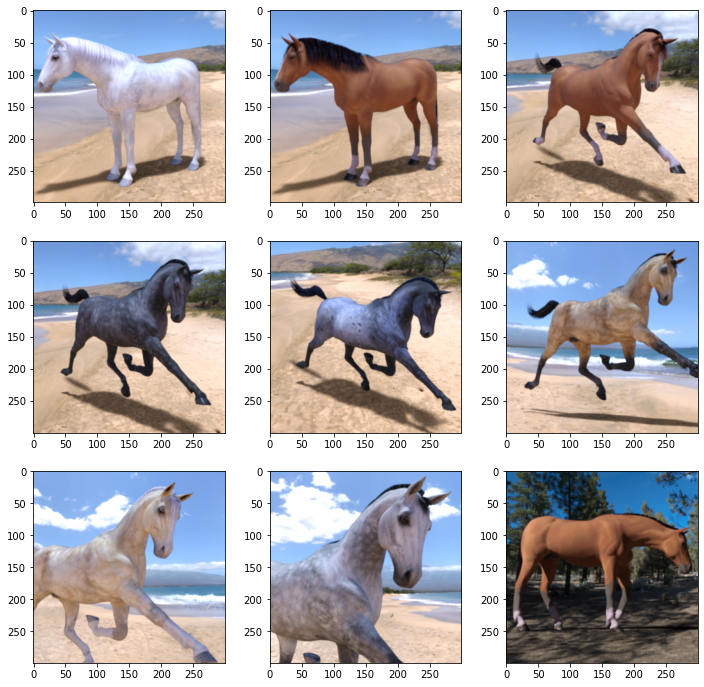

```python
# Plot some horse photos from the dataset
fig = plt.figure(figsize=(12,12))
for i in range(9):
	plt.subplot(330 + 1 + i)
	filename = train_horse_dir + '/horse0' + str(i+1) + '-1.png'
	image = mpimg.imread(filename)
	plt.imshow(image)
plt.show()
```

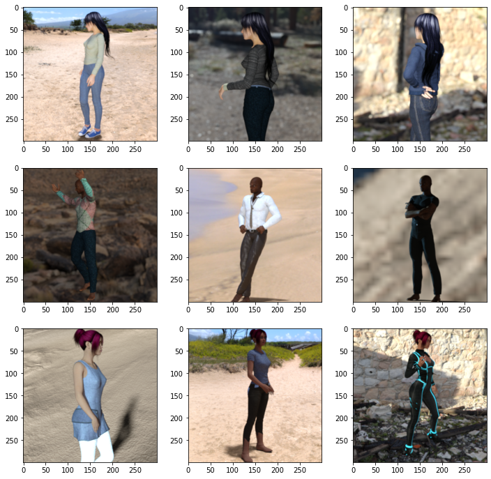

```python
# Plot some human photos from the dataset
fig = plt.figure(figsize=(12,12))
for i in range(9):
	plt.subplot(330 + 1 + i)
	filename = train_human_dir + '/human0' + str(i+1) + '-01.png'
	image = mpimg.imread(filename)
	plt.imshow(image)
plt.show()
```

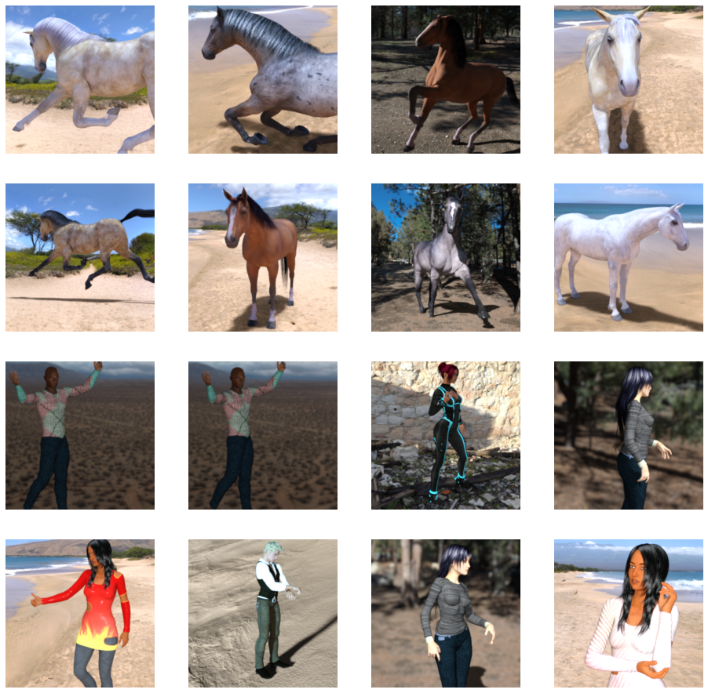

```python
# Parameters for our graph; we'll output images in a 4x4 configuration
nrows = 4
ncols = 4

# Index for iterating over images
pic_index = 0

# Set up matplotlib fig, and size it to fit 4x4 pics
fig = plt.gcf()
fig.set_size_inches(ncols * 4, nrows * 4)

pic_index += 8
next_horse_pix = [os.path.join(train_horse_dir, fname)
                for fname in train_horse_names[pic_index-8:pic_index]]
next_human_pix = [os.path.join(train_human_dir, fname)
                for fname in train_human_names[pic_index-8:pic_index]]

for i, img_path in enumerate(next_horse_pix+next_human_pix):
  # Set up subplot; subplot indices start at 1
  sp = plt.subplot(nrows, ncols, i + 1)
  sp.axis('Off') # Don't show axes (or gridlines)

  img = mpimg.imread(img_path)
  plt.imshow(img)

plt.show()
```

```python
if (notifyStatus): status_notify("Task 2. Load and Prepare Data completed! "+datetime.now().strftime('%a %B %d, %Y %I:%M:%S %p'))
```

# Task 3. Define and Train Model

```python
if (notifyStatus): status_notify("Task 3. Define and Train Model has begun! "+datetime.now().strftime('%a %B %d, %Y %I:%M:%S %p'))
```

```python
# Define the function for plotting training results for comparison
def plot_metrics(history):
    fig, axs = plt.subplots(1, 2, figsize=(24, 15))
    metrics =  [train_loss, train_metric]
    for n, metric in enumerate(metrics):
        name = metric.replace("_"," ").capitalize()
        plt.subplot(2,2,n+1)
        plt.plot(history.epoch, history.history[metric], color='blue', label='Train')
        plt.plot(history.epoch, history.history['val_'+metric], color='red', linestyle="--", label='Val')
        plt.xlabel('Epoch')
        plt.ylabel(name)
        if metric == train_loss:
            plt.ylim([0, plt.ylim()[1]])
        else:
            plt.ylim([0.5, 1.1])
        plt.legend()
```

```python
# All images will be rescaled by 1./255
train_datagen = ImageDataGenerator(rescale=1/255)
validation_datagen = ImageDataGenerator(rescale=1/255)

# Flow training images in batches of 128 using train_datagen generator
train_generator = train_datagen.flow_from_directory(
        train_dir,  # This is the source directory for training images
        target_size=default_image_size,  # All images will be resized to 300x300
        batch_size=default_batch,
        # Since we use binary_crossentropy loss, we need binary labels
        class_mode='binary')

# Flow training images in batches of 128 using train_datagen generator
validation_generator = validation_datagen.flow_from_directory(
        validation_dir,  # This is the source directory for training images
        target_size=default_image_size,  # All images will be resized to 300x300
        batch_size=default_batch,
        # Since we use binary_crossentropy loss, we need binary labels
        class_mode='binary')
```

```
Found 1027 images belonging to 2 classes.
Found 256 images belonging to 2 classes.
```

```python
# Define the baseline model for benchmarking
def create_nn_model(conv1_filters=16, conv2_filters=32, conv3_filters=64, conv4_filters=64, conv5_filters=64,
                    conv1_dropout=0, conv2_dropout=0, conv3_dropout=0, conv4_dropout=0, conv5_dropout=0,
                    dense_nodes=512, dense_dropout=0, opt_param=default_optimizer, init_param=default_kernel_init):
    nn_model = keras.Sequential([
        # Note the input shape is the desired size of the image 300x300 with 3 bytes color
        # This is the first convolution
        keras.layers.Conv2D(conv1_filters, (3,3), padding='same', activation='relu', kernel_initializer=init_param, input_shape=(300, 300, 3)),
        keras.layers.MaxPooling2D(2,2),
        # keras.layers.Dropout(conv1_dropout),
        # This is the second convolution
        keras.layers.Conv2D(conv2_filters, (3,3), padding='same', activation='relu', kernel_initializer=init_param),
        keras.layers.MaxPooling2D(2,2),
        # keras.layers.Dropout(conv2_dropout),
        # This is the third convolution
        keras.layers.Conv2D(conv3_filters, (3,3), padding='same', activation='relu', kernel_initializer=init_param),
        keras.layers.MaxPooling2D(2,2),
        # keras.layers.Dropout(conv3_dropout),
        # This is the fourth convolution
        keras.layers.Conv2D(conv4_filters, (3,3), padding='same', activation='relu', kernel_initializer=init_param),
        keras.layers.MaxPooling2D(2,2),
        # keras.layers.Dropout(conv4_dropout),
        # This is the fifth convolution
        keras.layers.Conv2D(conv5_filters, (3,3), padding='same', activation='relu', kernel_initializer=init_param),
        keras.layers.MaxPooling2D(2,2),
        # keras.layers.Dropout(conv5_dropout),
        # Flatten the results to feed into a DNN
        keras.layers.Flatten(),
        # keras.layers.Dropout(dense_dropout),
        # 512 neuron hidden layer
        keras.layers.Dense(dense_nodes, activation='relu', kernel_initializer=init_param),
        # Only 1 output neuron. It will contain a value from 0-1 where 0 for 1 class ('horses') and 1 for the other ('humans')
        keras.layers.Dense(1, activation='sigmoid', kernel_initializer=init_param)
    ])
    nn_model.compile(loss=default_loss, optimizer=opt_param, metrics=default_metrics)
    return nn_model
```

```python
# Initialize the default model and get a baseline result
startTimeModule = datetime.now()
reset_random(seedNum)
baseline_model = create_nn_model()
baseline_history = baseline_model.fit(
    train_generator,
    steps_per_epoch=len(train_generator),
	validation_data=validation_generator,
    validation_steps=len(validation_generator),
    epochs=default_epoch,
    verbose=1)
print('Total time for model fitting:', (datetime.now() - startTimeModule))
```

```
Total time for model fitting: 0:01:56.717074
```

```python
baseline_model.summary()
```

```
Model: "sequential"
_________________________________________________________________
Layer (type)                 Output Shape              Param #
=================================================================
conv2d (Conv2D)              (None, 300, 300, 16)      448
_________________________________________________________________
max_pooling2d (MaxPooling2D) (None, 150, 150, 16)      0
_________________________________________________________________
conv2d_1 (Conv2D)            (None, 150, 150, 32)      4640
_________________________________________________________________
max_pooling2d_1 (MaxPooling2 (None, 75, 75, 32)        0
_________________________________________________________________
conv2d_2 (Conv2D)            (None, 75, 75, 64)        18496
_________________________________________________________________
max_pooling2d_2 (MaxPooling2 (None, 37, 37, 64)        0
_________________________________________________________________
conv2d_3 (Conv2D)            (None, 37, 37, 64)        36928
_________________________________________________________________
max_pooling2d_3 (MaxPooling2 (None, 18, 18, 64)        0
_________________________________________________________________
conv2d_4 (Conv2D)            (None, 18, 18, 64)        36928
_________________________________________________________________
max_pooling2d_4 (MaxPooling2 (None, 9, 9, 64)          0
_________________________________________________________________
flatten (Flatten)            (None, 5184)              0
_________________________________________________________________
dense (Dense)                (None, 512)               2654720
_________________________________________________________________
dense_1 (Dense)              (None, 1)                 513
=================================================================
Total params: 2,752,673
Trainable params: 2,752,673
Non-trainable params: 0
_________________________________________________________________
```

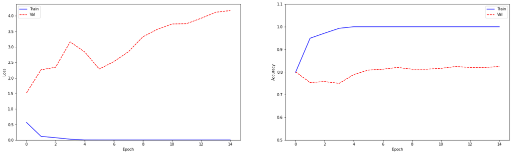

```python
plot_metrics(baseline_history)
```

```python
if (notifyStatus): status_notify("Task 3. Define and Train Model completed! "+datetime.now().strftime('%a %B %d, %Y %I:%M:%S %p'))
```

# Task 4. Evaluate and Optimize Model

```python
if (notifyStatus): status_notify("Task 4. Evaluate and Optimize Model has begun! "+datetime.now().strftime('%a %B %d, %Y %I:%M:%S %p'))
```

## 4.a) Experiment with Three VGG Blocks and Two Convolution Layer Each Block

```python
# Define the baseline model for benchmarking
def create_model_4a(conv1_filters=16, conv2_filters=32, conv3_filters=64, conv4_filters=64, conv5_filters=64,
                    conv1_dropout=0, conv2_dropout=0.3, conv3_dropout=0.3, conv4_dropout=0, conv5_dropout=0,
                    dense_nodes=512, dense_dropout=0.3, opt_param=default_optimizer, init_param=default_kernel_init):
    nn_model_4a = keras.Sequential([
        # Note the input shape is the desired size of the image 300x300 with 3 bytes color
        # This is the first convolution
        keras.layers.Conv2D(conv1_filters, (3,3), padding='same', activation='relu', kernel_initializer=init_param, input_shape=(300, 300, 3)),
        keras.layers.Dropout(conv1_dropout),
        keras.layers.MaxPooling2D(2,2),
        # This is the second convolution
        keras.layers.Conv2D(conv2_filters, (3,3), padding='same', activation='relu', kernel_initializer=init_param),
        keras.layers.Conv2D(conv2_filters, (3,3), padding='same', activation='relu', kernel_initializer=init_param),
        keras.layers.Dropout(conv2_dropout),
        keras.layers.MaxPooling2D(2,2),
        # This is the third convolution
        keras.layers.Conv2D(conv3_filters, (3,3), padding='same', activation='relu', kernel_initializer=init_param),
        keras.layers.Conv2D(conv3_filters, (3,3), padding='same', activation='relu', kernel_initializer=init_param),
        keras.layers.Dropout(conv3_dropout),
        keras.layers.MaxPooling2D(2,2),
        # Flatten the results to feed into a DNN
        keras.layers.Flatten(),
        keras.layers.Dropout(dense_dropout),
        # 512 neuron hidden layer
        keras.layers.Dense(dense_nodes, activation='relu', kernel_initializer=init_param),
        # Only 1 output neuron. It will contain a value from 0-1 where 0 for 1 class ('horses') and 1 for the other ('humans')
        keras.layers.Dense(1, activation='sigmoid', kernel_initializer=init_param)
    ])
    nn_model_4a.compile(loss=default_loss, optimizer=opt_param, metrics=default_metrics)
    return nn_model_4a
```

```python
# Initialize the default model and get a baseline result
startTimeModule = datetime.now()
reset_random(seedNum)
nn_model_4a = create_model_4a()
nn_model_4a_history = nn_model_4a.fit(
    train_generator,
    steps_per_epoch=len(train_generator),
	validation_data=validation_generator,
    validation_steps=len(validation_generator),
    epochs=default_epoch,
    verbose=1)
print('Total time for model fitting:', (datetime.now() - startTimeModule))
```

```
Total time for model fitting: 0:01:56.409443
```

```python
nn_model_4a.summary()
```

```
Model: "sequential_1"
_________________________________________________________________
Layer (type)                 Output Shape              Param #
=================================================================
conv2d_5 (Conv2D)            (None, 300, 300, 16)      448
_________________________________________________________________
dropout (Dropout)            (None, 300, 300, 16)      0
_________________________________________________________________
max_pooling2d_5 (MaxPooling2 (None, 150, 150, 16)      0
_________________________________________________________________
conv2d_6 (Conv2D)            (None, 150, 150, 32)      4640
_________________________________________________________________
conv2d_7 (Conv2D)            (None, 150, 150, 32)      9248
_________________________________________________________________
dropout_1 (Dropout)          (None, 150, 150, 32)      0
_________________________________________________________________
max_pooling2d_6 (MaxPooling2 (None, 75, 75, 32)        0
_________________________________________________________________
conv2d_8 (Conv2D)            (None, 75, 75, 64)        18496
_________________________________________________________________
conv2d_9 (Conv2D)            (None, 75, 75, 64)        36928
_________________________________________________________________
dropout_2 (Dropout)          (None, 75, 75, 64)        0
_________________________________________________________________
max_pooling2d_7 (MaxPooling2 (None, 37, 37, 64)        0
_________________________________________________________________
flatten_1 (Flatten)          (None, 87616)             0
_________________________________________________________________
dropout_3 (Dropout)          (None, 87616)             0
_________________________________________________________________
dense_2 (Dense)              (None, 512)               44859904
_________________________________________________________________
dense_3 (Dense)              (None, 1)                 513
=================================================================
Total params: 44,930,177
Trainable params: 44,930,177
Non-trainable params: 0
_________________________________________________________________
```

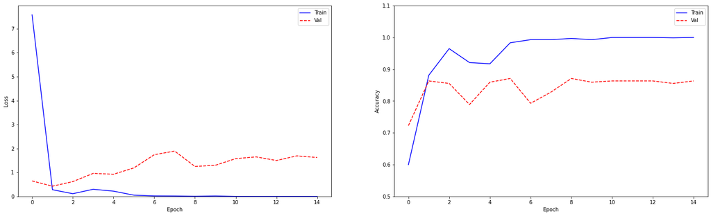

```python
plot_metrics(nn_model_4a_history)
```

## 4.b) Experiment with Four VGG Blocks and Two Convolution Layers Each Block

```python
# Define the baseline model for benchmarking
def create_model_4b(conv1_filters=16, conv2_filters=32, conv3_filters=64, conv4_filters=64, conv5_filters=64,
                    conv1_dropout=0, conv2_dropout=0.3, conv3_dropout=0.3, conv4_dropout=0, conv5_dropout=0,
                    dense_nodes=512, dense_dropout=0.3, opt_param=default_optimizer, init_param=default_kernel_init):
    nn_model_4b = keras.Sequential([
        # Note the input shape is the desired size of the image 300x300 with 3 bytes color
        # This is the first convolution
        keras.layers.Conv2D(conv1_filters, (3,3), padding='same', activation='relu', kernel_initializer=init_param, input_shape=(300, 300, 3)),
        keras.layers.Dropout(conv1_dropout),
        keras.layers.MaxPooling2D(2,2),
        # This is the second convolution
        keras.layers.Conv2D(conv2_filters, (3,3), padding='same', activation='relu', kernel_initializer=init_param),
        keras.layers.Conv2D(conv2_filters, (3,3), padding='same', activation='relu', kernel_initializer=init_param),
        keras.layers.Dropout(conv2_dropout),
        keras.layers.MaxPooling2D(2,2),
        # This is the third convolution
        keras.layers.Conv2D(conv3_filters, (3,3), padding='same', activation='relu', kernel_initializer=init_param),
        keras.layers.Conv2D(conv3_filters, (3,3), padding='same', activation='relu', kernel_initializer=init_param),
        keras.layers.Dropout(conv3_dropout),
        keras.layers.MaxPooling2D(2,2),
        # This is the fourth convolution
        keras.layers.Conv2D(conv4_filters, (3,3), padding='same', activation='relu', kernel_initializer=init_param),
        keras.layers.Conv2D(conv4_filters, (3,3), padding='same', activation='relu', kernel_initializer=init_param),
        keras.layers.Dropout(conv4_dropout),
        keras.layers.MaxPooling2D(2,2),
        # Flatten the results to feed into a DNN
        keras.layers.Flatten(),
        keras.layers.Dropout(dense_dropout),
        # 512 neuron hidden layer
        keras.layers.Dense(dense_nodes, activation='relu', kernel_initializer=init_param),
        # Only 1 output neuron. It will contain a value from 0-1 where 0 for 1 class ('horses') and 1 for the other ('humans')
        keras.layers.Dense(1, activation='sigmoid', kernel_initializer=init_param)
    ])
    nn_model_4b.compile(loss=default_loss, optimizer=opt_param, metrics=default_metrics)
    return nn_model_4b
```

```python
# Initialize the default model and get a baseline result
startTimeModule = datetime.now()
reset_random(seedNum)
nn_model_4b = create_model_4b()
nn_model_4b_history = nn_model_4b.fit(
    train_generator,
    steps_per_epoch=len(train_generator),
	validation_data=validation_generator,
    validation_steps=len(validation_generator),
    epochs=default_epoch,
    verbose=1)
print('Total time for model fitting:', (datetime.now() - startTimeModule))
```

```
Total time for model fitting: 0:01:56.600514
```

```python
nn_model_4b.summary()
```

```
Model: "sequential_2"
_________________________________________________________________
Layer (type)                 Output Shape              Param #
=================================================================
conv2d_10 (Conv2D)           (None, 300, 300, 16)      448
_________________________________________________________________
dropout_4 (Dropout)          (None, 300, 300, 16)      0
_________________________________________________________________
max_pooling2d_8 (MaxPooling2 (None, 150, 150, 16)      0
_________________________________________________________________
conv2d_11 (Conv2D)           (None, 150, 150, 32)      4640
_________________________________________________________________
conv2d_12 (Conv2D)           (None, 150, 150, 32)      9248
_________________________________________________________________
dropout_5 (Dropout)          (None, 150, 150, 32)      0
_________________________________________________________________
max_pooling2d_9 (MaxPooling2 (None, 75, 75, 32)        0
_________________________________________________________________
conv2d_13 (Conv2D)           (None, 75, 75, 64)        18496
_________________________________________________________________
conv2d_14 (Conv2D)           (None, 75, 75, 64)        36928
_________________________________________________________________
dropout_6 (Dropout)          (None, 75, 75, 64)        0
_________________________________________________________________
max_pooling2d_10 (MaxPooling (None, 37, 37, 64)        0
_________________________________________________________________
conv2d_15 (Conv2D)           (None, 37, 37, 64)        36928
_________________________________________________________________
conv2d_16 (Conv2D)           (None, 37, 37, 64)        36928
_________________________________________________________________
dropout_7 (Dropout)          (None, 37, 37, 64)        0
_________________________________________________________________
max_pooling2d_11 (MaxPooling (None, 18, 18, 64)        0
_________________________________________________________________
flatten_2 (Flatten)          (None, 20736)             0
_________________________________________________________________
dropout_8 (Dropout)          (None, 20736)             0
_________________________________________________________________
dense_4 (Dense)              (None, 512)               10617344
_________________________________________________________________
dense_5 (Dense)              (None, 1)                 513
=================================================================
Total params: 10,761,473
Trainable params: 10,761,473
Non-trainable params: 0
_________________________________________________________________
```

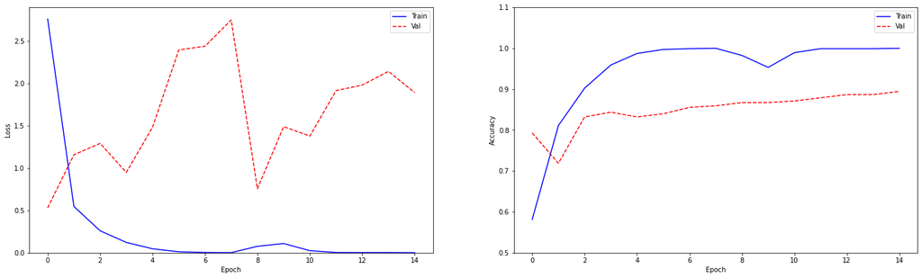

```python
plot_metrics(nn_model_4b_history)
```

## 4.c) Experiment with Five VGG Blocks, One Convolution Layer, and Dropout Each Block

```python
# Define the baseline model for benchmarking
def create_model_4c(conv1_filters=16, conv2_filters=32, conv3_filters=64, conv4_filters=64, conv5_filters=64,
                    conv1_dropout=0, conv2_dropout=0.3, conv3_dropout=0.3, conv4_dropout=0, conv5_dropout=0,
                    dense_nodes=512, dense_dropout=0.3, opt_param=default_optimizer, init_param=default_kernel_init):
    nn_model_4c = keras.Sequential([
        # Note the input shape is the desired size of the image 300x300 with 3 bytes color
        # This is the first convolution
        keras.layers.Conv2D(conv1_filters, (3,3), padding='same', activation='relu', kernel_initializer=init_param, input_shape=(300, 300, 3)),
        keras.layers.Dropout(conv1_dropout),
        keras.layers.MaxPooling2D(2,2),
        # This is the second convolution
        keras.layers.Conv2D(conv2_filters, (3,3), padding='same', activation='relu', kernel_initializer=init_param),
        keras.layers.Dropout(conv2_dropout),
        keras.layers.MaxPooling2D(2,2),
        # This is the third convolution
        keras.layers.Conv2D(conv3_filters, (3,3), padding='same', activation='relu', kernel_initializer=init_param),
        keras.layers.Dropout(conv3_dropout),
        keras.layers.MaxPooling2D(2,2),
        # This is the fourth convolution
        keras.layers.Conv2D(conv4_filters, (3,3), padding='same', activation='relu', kernel_initializer=init_param),
        keras.layers.Dropout(conv4_dropout),
        keras.layers.MaxPooling2D(2,2),
        # This is the fifth convolution
        keras.layers.Conv2D(conv5_filters, (3,3), padding='same', activation='relu', kernel_initializer=init_param),
        keras.layers.Dropout(conv5_dropout),
        keras.layers.MaxPooling2D(2,2),
        # Flatten the results to feed into a DNN
        keras.layers.Flatten(),
        keras.layers.Dropout(dense_dropout),
        # 512 neuron hidden layer
        keras.layers.Dense(dense_nodes, activation='relu', kernel_initializer=init_param),
        # Only 1 output neuron. It will contain a value from 0-1 where 0 for 1 class ('horses') and 1 for the other ('humans')
        keras.layers.Dense(1, activation='sigmoid', kernel_initializer=init_param)
    ])
    nn_model_4c.compile(loss=default_loss, optimizer=opt_param, metrics=default_metrics)
    return nn_model_4c
```

```python
# Initialize the default model and get a baseline result
startTimeModule = datetime.now()
reset_random(seedNum)
nn_model_4c = create_model_4c()
nn_model_4c_history = nn_model_4c.fit(
    train_generator,
    steps_per_epoch=len(train_generator),
	validation_data=validation_generator,
    validation_steps=len(validation_generator),
    epochs=default_epoch,
    verbose=1)
print('Total time for model fitting:', (datetime.now() - startTimeModule))
```

```
Total time for model fitting: 0:01:53.435901
```

```python
nn_model_4c.summary()
```

```
Model: "sequential_3"
_________________________________________________________________
Layer (type)                 Output Shape              Param #
=================================================================
conv2d_17 (Conv2D)           (None, 300, 300, 16)      448
_________________________________________________________________
dropout_9 (Dropout)          (None, 300, 300, 16)      0
_________________________________________________________________
max_pooling2d_12 (MaxPooling (None, 150, 150, 16)      0
_________________________________________________________________
conv2d_18 (Conv2D)           (None, 150, 150, 32)      4640
_________________________________________________________________
dropout_10 (Dropout)         (None, 150, 150, 32)      0
_________________________________________________________________
max_pooling2d_13 (MaxPooling (None, 75, 75, 32)        0
_________________________________________________________________
conv2d_19 (Conv2D)           (None, 75, 75, 64)        18496
_________________________________________________________________
dropout_11 (Dropout)         (None, 75, 75, 64)        0
_________________________________________________________________
max_pooling2d_14 (MaxPooling (None, 37, 37, 64)        0
_________________________________________________________________
conv2d_20 (Conv2D)           (None, 37, 37, 64)        36928
_________________________________________________________________
dropout_12 (Dropout)         (None, 37, 37, 64)        0
_________________________________________________________________
max_pooling2d_15 (MaxPooling (None, 18, 18, 64)        0
_________________________________________________________________
conv2d_21 (Conv2D)           (None, 18, 18, 64)        36928
_________________________________________________________________
dropout_13 (Dropout)         (None, 18, 18, 64)        0
_________________________________________________________________
max_pooling2d_16 (MaxPooling (None, 9, 9, 64)          0
_________________________________________________________________
flatten_3 (Flatten)          (None, 5184)              0
_________________________________________________________________
dropout_14 (Dropout)         (None, 5184)              0
_________________________________________________________________
dense_6 (Dense)              (None, 512)               2654720
_________________________________________________________________
dense_7 (Dense)              (None, 1)                 513
=================================================================
Total params: 2,752,673
Trainable params: 2,752,673
Non-trainable params: 0
_________________________________________________________________
```

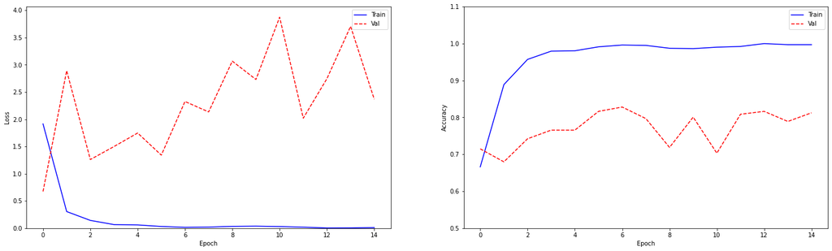

```python
plot_metrics(nn_model_4c_history)
```

```python
if (notifyStatus): status_notify("Task 4. Evaluate and Optimize Model completed! "+datetime.now().strftime('%a %B %d, %Y %I:%M:%S %p'))
```

# Task 5. Finalize Model and Make Predictions

```python
if (notifyStatus): status_notify("Task 5. Finalize Model and Make Predictions has begun! "+datetime.now().strftime('%a %B %d, %Y %I:%M:%S %p'))
```

```python
final_model = nn_model_4b

# Display a summary of the final model
final_model.summary()
```

```
Model: "sequential_2"
_________________________________________________________________
Layer (type)                 Output Shape              Param #
=================================================================
conv2d_10 (Conv2D)           (None, 300, 300, 16)      448
_________________________________________________________________
dropout_4 (Dropout)          (None, 300, 300, 16)      0
_________________________________________________________________
max_pooling2d_8 (MaxPooling2 (None, 150, 150, 16)      0
_________________________________________________________________
conv2d_11 (Conv2D)           (None, 150, 150, 32)      4640
_________________________________________________________________
conv2d_12 (Conv2D)           (None, 150, 150, 32)      9248
_________________________________________________________________
dropout_5 (Dropout)          (None, 150, 150, 32)      0
_________________________________________________________________
max_pooling2d_9 (MaxPooling2 (None, 75, 75, 32)        0
_________________________________________________________________
conv2d_13 (Conv2D)           (None, 75, 75, 64)        18496
_________________________________________________________________
conv2d_14 (Conv2D)           (None, 75, 75, 64)        36928
_________________________________________________________________
dropout_6 (Dropout)          (None, 75, 75, 64)        0
_________________________________________________________________
max_pooling2d_10 (MaxPooling (None, 37, 37, 64)        0
_________________________________________________________________
conv2d_15 (Conv2D)           (None, 37, 37, 64)        36928
_________________________________________________________________
conv2d_16 (Conv2D)           (None, 37, 37, 64)        36928
_________________________________________________________________
dropout_7 (Dropout)          (None, 37, 37, 64)        0
_________________________________________________________________
max_pooling2d_11 (MaxPooling (None, 18, 18, 64)        0
_________________________________________________________________
flatten_2 (Flatten)          (None, 20736)             0
_________________________________________________________________
dropout_8 (Dropout)          (None, 20736)             0
_________________________________________________________________
dense_4 (Dense)              (None, 512)               10617344
_________________________________________________________________
dense_5 (Dense)              (None, 1)                 513
=================================================================
Total params: 10,761,473
Trainable params: 10,761,473
Non-trainable params: 0
_________________________________________________________________
```

```python
if (notifyStatus): status_notify("Phase 5 Finalize Model and Make Predictions completed! "+datetime.now().strftime('%a %B %d, %Y %I:%M:%S %p'))
```

```python
print ('Total time for the script:',(datetime.now() - startTimeScript))
```

```
Total time for the script: 0:08:04.926192
```